# 05Project_01

Adolfo Hoyos Díaz

May 4, 2017

# Dependencies

[output not shown]

# Load data

We start by creating a variable to store the number of cluster on which we are basing our clustering analysis

```r
k <- 4
```

Now, we load the provided files:

```r
pathways.values <- as.data.frame(read.table("../data/pathways.values"))
pathways.scores <- as.data.frame(read.table("../data/pathways.scores"))
```

And show some information about the **scores** file, which is a PCA version of the **pathways.values** file:

```r
summary(pathways.scores)
```

```
##       RC1                RC2               RC3
##  Min.   :-2.67301   Min.   :-3.7695   Min.   :-2.0593
##  1st Qu.:-0.81552   1st Qu.:-0.8416   1st Qu.:-0.6892
##  Median : 0.05727   Median : 0.1617   Median :-0.2581
##  Mean   : 0.00000   Mean   : 0.0000   Mean   : 0.0000
##  3rd Qu.: 0.83007   3rd Qu.: 0.8116   3rd Qu.: 0.4470
##  Max.   : 2.90909   Max.   : 2.1114   Max.   : 3.5579
```

```r
colnames(pathways.scores)
```

```
## [1] "RC1" "RC2" "RC3"
```

# Hierarchical clustering

In this section we will perform a hierarchical clustering of both datasets. For that, we define a function that does this using a complete hierarchical scheme, and Euclidean distance:

```r
my.hclust <- function(x, method = "complete", dmeth = "euclidean"){
  hclust(dist(x, method = dmeth), method = method)
}
```

And, of course, we apply this function to both datasets:

```r
hierarch.clusters.reduced <- my.hclust(pathways.scores)
hierarch.clusters.structural <- my.hclust(pathways.values)
```

The name “*reduced*” refers to the reduced nature of the **scores** dataset, which was generated using PCA over the **pathways.values** file. The latter is an original dataset containing structural information.

Now, we transform these datasets to dendogram representations and add some color

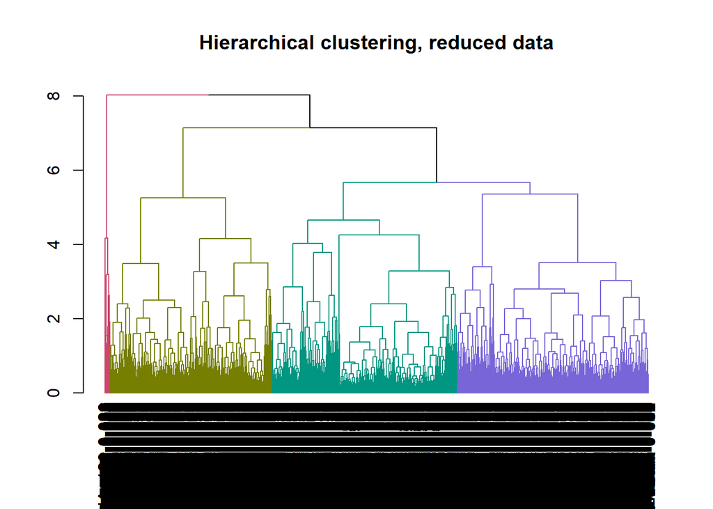

```r
hierarch.cluster.dendrogram.reduced <- as.dendrogram(hierarch.clusters.reduced)
hierarch.cluster.dendrogram.reduced <- color_branches(hierarch.cluster.dendrogram.reduced, k = k)
plot(hierarch.cluster.dendrogram.reduced, main = "Hierarchical clustering, reduced data")
```

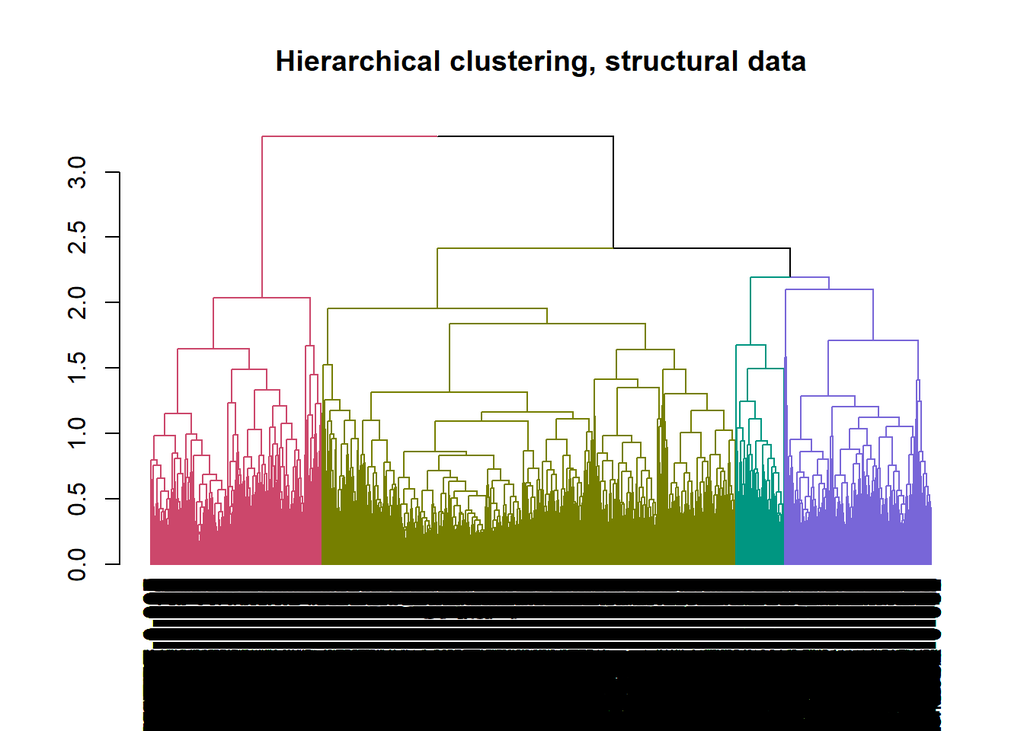

```r
hierarch.cluster.dendrogram.structural <- as.dendrogram(hierarch.clusters.structural)
hierarch.cluster.dendrogram.structural <- color_branches(hierarch.cluster.dendrogram.structural, k = k)
plot(hierarch.cluster.dendrogram.structural, main = "Hierarchical clustering, structural data")
```

As this clusering method produces as much branches as datapoints, we cut these trees to only have *k* branches:

```r
hierarch.clusters.cut.reduced <- cutree(hierarch.cluster.dendrogram.reduced, k)
hierarch.clusters.cut.structural <- cutree(hierarch.cluster.dendrogram.structural, k)
```

And we visualize both results

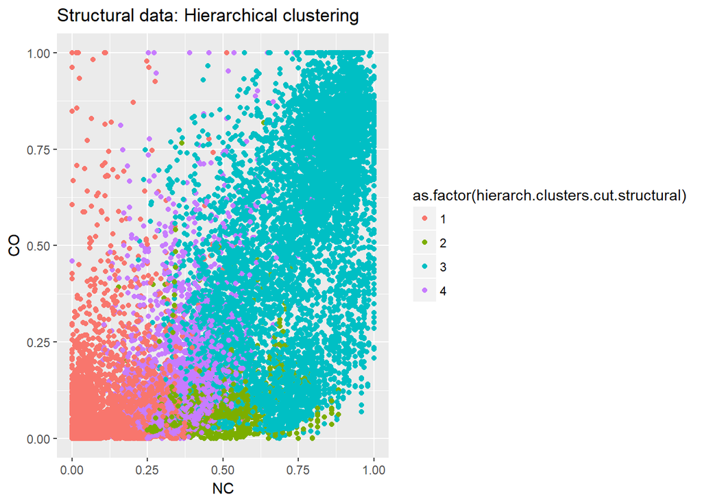

```r
ggplot(pathways.values, aes(NC, CO, color = as.factor(hierarch.clusters.cut.structural))
) + geom_point() + ggtitle("Structural data: Hierarchical clustering")
```

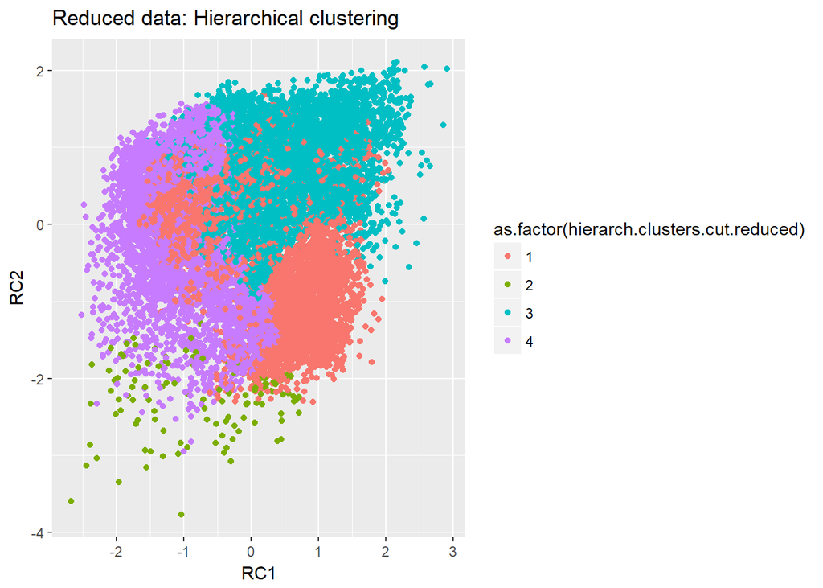

```r
ggplot(pathways.scores, aes(RC1, RC2, color = as.factor(hierarch.clusters.cut.reduced))
) + geom_point() + ggtitle("Reduced data: Hierarchical clustering")
```

Finally, we visualize how many datapoints were grouped in the clusters:

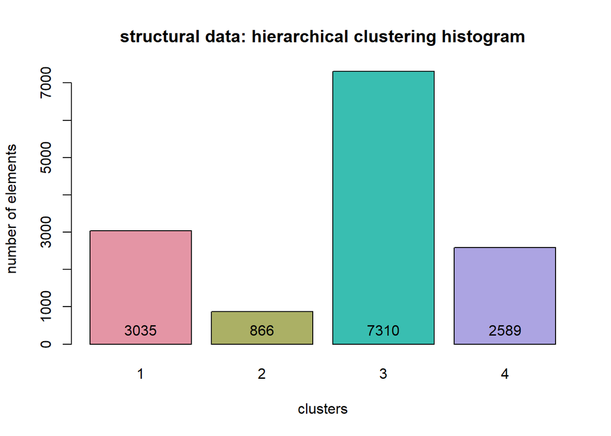

```r
plot.colors <- rainbow_hcl(k)

hierarch.clusters.table.structural <- table(hierarch.clusters.cut.structural)
bp <- barplot(hierarch.clusters.table.structural, col = plot.colors,
              xlab = "clusters", ylab = "number of elements",
              main = "structural data: hierarchical clustering histogram")
text(bp, 0, hierarch.clusters.table.structural, cex = 1, pos = 3)
```

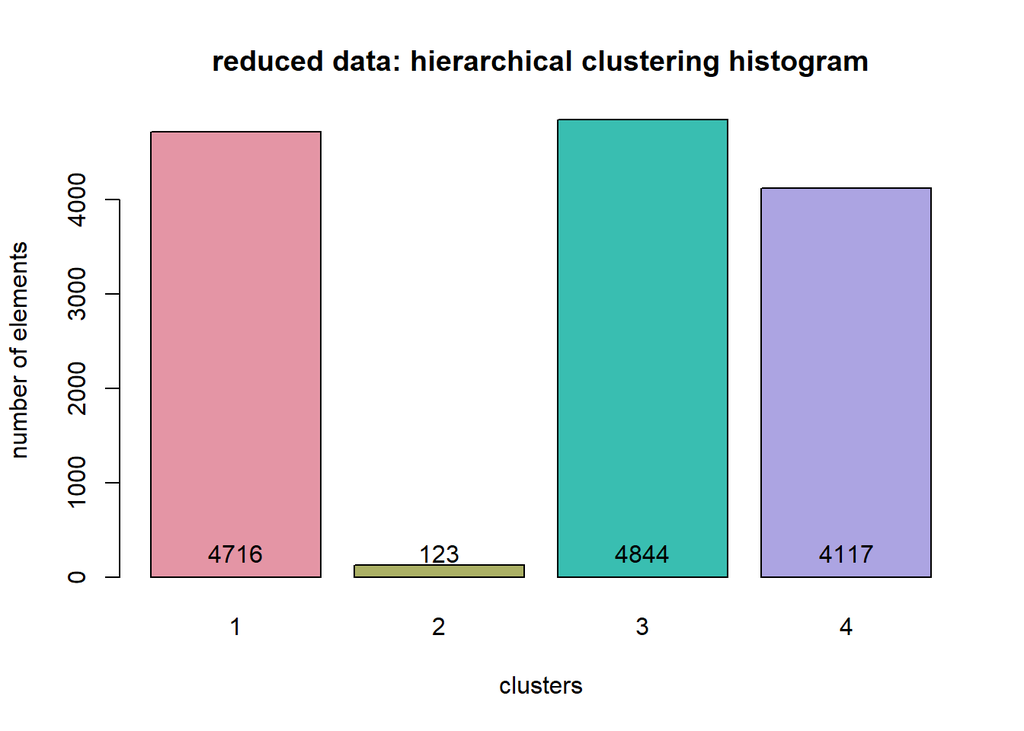

```r
hierarch.clusters.table.reduced <- table(hierarch.clusters.cut.reduced)
bp <- barplot(hierarch.clusters.table.reduced, col = plot.colors,
              xlab = "clusters", ylab = "number of elements",
              main = "reduced data: hierarchical clustering histogram")
text(bp, 0, hierarch.clusters.table.reduced, cex = 1, pos = 3)
```

# K-means clustering

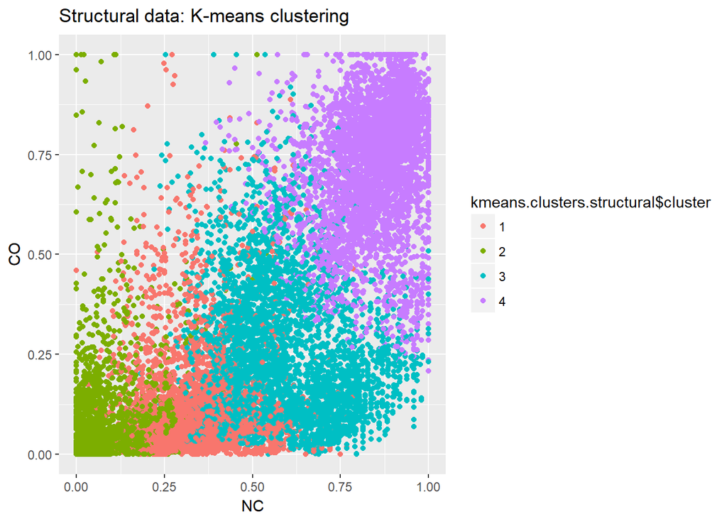

```r
kmeans.clusters.structural <- kmeans(pathways.values, centers = 4, nstart = 30)
kmeans.clusters.structural$cluster <- as.factor(kmeans.clusters.structural$cluster)

ggplot(pathways.values, aes(NC, CO, color = kmeans.clusters.structural$cluster)
       ) + geom_point() + ggtitle("Structural data: K-means clustering")
```

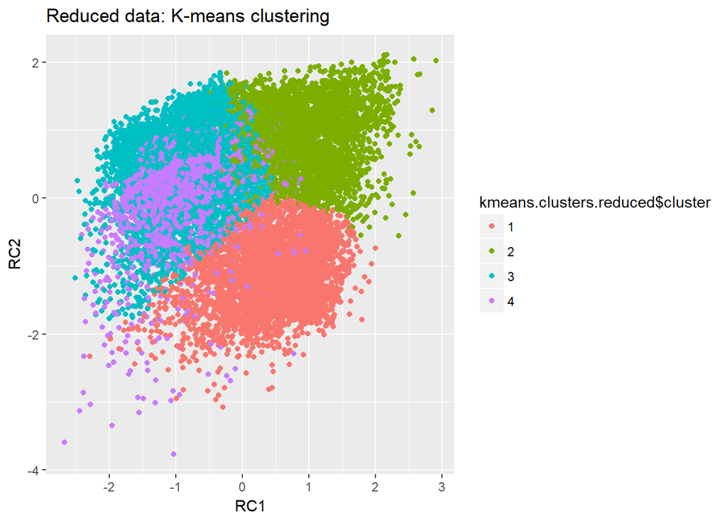

```r
kmeans.clusters.reduced <- kmeans(pathways.scores, centers = 4, nstart = 30)
kmeans.clusters.reduced$cluster <- as.factor(kmeans.clusters.reduced$cluster)

ggplot(pathways.scores, aes(RC1, RC2, color = kmeans.clusters.reduced$cluster)
) + geom_point() + ggtitle("Reduced data: K-means clustering")
```

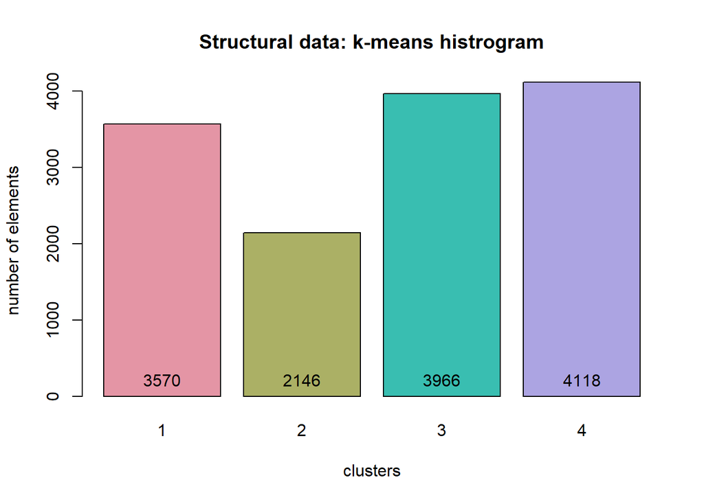

```r
kmeans.clusters.table.structural <- table(kmeans.clusters.structural$cluster)

bp <- barplot(kmeans.clusters.table.structural, col = plot.colors, xlab = "clusters", ylab = "number of elements",
              main = "Structural data: k-means histrogram")
text(bp, 0, kmeans.clusters.table.structural, cex = 1, pos = 3)
```

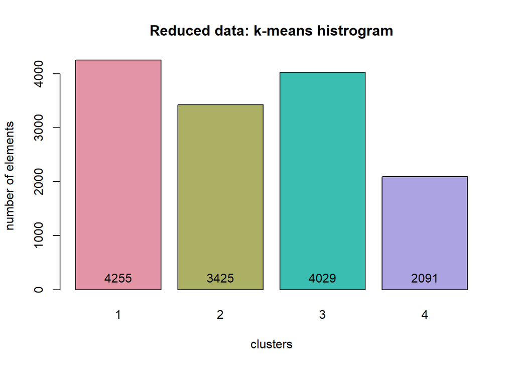

```r
kmeans.clusters.table.reduced <- table(kmeans.clusters.reduced$cluster)

bp <- barplot(kmeans.clusters.table.reduced, col = plot.colors, xlab = "clusters", ylab = "number of elements",
              main = "Reduced data: k-means histrogram")
text(bp, 0, kmeans.clusters.table.reduced, cex = 1, pos = 3)
```

# Jaccard coefficient

```r
my.jaccard.coefficient <- function(labels1, cluster1, labels2, cluster2){
  labels1.comparisson <- labels1 == cluster1
  labels2.comparisson <- labels2 == cluster2
  return (sum(labels1.comparisson & labels2.comparisson ) / sum(labels1.comparisson | labels2.comparisson ))
}
```

```r
my.jaccard.matrix <- function(labels1, labels2, k){
  labels1 <- as.array(labels1)
  labels2 <- as.array(labels2)
  jaccard.hierarchical  <- matrix(nrow = k, ncol = k)
  max.coeffs.positions  <- array()
  max.coeffs            <- array()
  for (i in 1:k){
    max.coeffs.positions[i] <- 0
    max.coeffs[i] <- 0
    for(j in 1:k){
      jaccard.hierarchical[i,j] <- my.jaccard.coefficient(labels1, i, labels2, j)
      if (jaccard.hierarchical[i,j] > max.coeffs[i]){
        max.coeffs[i]           <- jaccard.hierarchical[i,j]
        max.coeffs.positions[i] <- j
      }
    }
  }
  return(list(jaccard.hierarchical, max.coeffs, max.coeffs.positions))
}
```

```r
jaccard.matrix.hierarchical <- my.jaccard.matrix(hierarch.clusters.cut.structural, hierarch.clusters.cut.reduced, k)
print(jaccard.matrix.hierarchical)
```

```
## [[1]]
##             [,1]        [,2]       [,3]      [,4]
## [1,] 0.251170299 0.017396907 0.07577826 0.1384909
## [2,] 0.026857984 0.000000000 0.14428858 0.0000000
## [3,] 0.327959364 0.006090958 0.28831885 0.1598660
## [4,] 0.006059771 0.008928571 0.12894897 0.3321414
##
## [[2]]
## [1] 0.2511703 0.1442886 0.3279594 0.3321414
##
## [[3]]
## [1] 1 3 1 4
```

```r
jaccard.matrix.kmeans <- my.jaccard.matrix(kmeans.clusters.structural$cluster, kmeans.clusters.reduced$cluster, k)
print(jaccard.matrix.kmeans)
```

```
## [[1]]
##             [,1]       [,2]       [,3]        [,4]
## [1,] 0.002819428 0.20292347 0.39687500 0.038334556
## [2,] 0.000000000 0.01217297 0.03642162 0.784000000
## [3,] 0.045263827 0.38511994 0.23761610 0.003312904
## [4,] 0.862322064 0.01657682 0.01469672 0.000000000
##
## [[2]]
## [1] 0.3968750 0.7840000 0.3851199 0.8623221
##
## [[3]]
## [1] 3 4 2 1
```